# PCA of Training Set

First let’s take a look at our dataset

```r
data = read.csv("data_train.csv")
dim(data)
```

```
[1] 508130     24
```

```r
head(data, 20)
```

|  | X | Unnamed..0 | Unnamed..0.1 | Timestamp | EDA_Mean | EDA_Min | EDA_Max | EDA_Std | EDA_Kurtosis | EDA_Skew | EDA_Num_Peaks | EDA_Amphitude | EDA_Duration | HR_Mean | HR_Min | HR_Max | HR_Std | HR_RMS | temp_Mean | temp_Min | temp_Max | temp_Std | sID | Stress_level |
| --- | --- | --- | --- | --- | --- | --- | --- | --- | --- | --- | --- | --- | --- | --- | --- | --- | --- | --- | --- | --- | --- | --- | --- | --- |
| 1 | 0 | 0 | 0 | 1587167248 | 0.3190962 | 0.258813 | 0.357470 | 0.031664050 | -0.75304099 | -0.78035380 | 1 | 0.098657 | 27.883318 | 61.05300 | 59.36 | 65.50 | 1.88679119 | 1.01768969 | 30.2410 | 30.21 | 30.27 | 0.016703293 | 94 | 0 |
| 2 | 1 | 1 | 1 | 1587167253 | 0.3252464 | 0.207563 | 0.395907 | 0.044520151 | -0.11561200 | -0.91620060 | 2 | 0.169126 | 21.361746 | 59.59950 | 59.20 | 60.67 | 0.45970616 | 0.11019796 | 30.2210 | 30.19 | 30.25 | 0.016703293 | 94 | 0 |
| 3 | 2 | 2 | 2 | 1587167258 | 0.3090705 | 0.207563 | 0.395907 | 0.041042629 | -0.07117096 | -0.03731672 | 1 | 0.134531 | 9.690575 | 59.13400 | 58.75 | 59.52 | 0.20722934 | 0.13437414 | 30.2010 | 30.17 | 30.23 | 0.016703293 | 94 | 0 |
| 4 | 3 | 3 | 3 | 1587167263 | 0.3071806 | 0.262657 | 0.315188 | 0.009251471 | 11.63671312 | -3.24405402 | 0 | 0.000000 | 0.000000 | 59.88175 | 58.75 | 61.96 | 1.02734339 | 0.22200139 | 30.1810 | 30.15 | 30.21 | 0.016703293 | 94 | 0 |
| 5 | 4 | 4 | 4 | 1587167268 | 0.3107361 | 0.307501 | 0.313907 | 0.001488449 | -0.11927337 | -0.25216230 | 0 | 0.000000 | 0.000000 | 61.74700 | 59.52 | 63.68 | 1.17259584 | 0.21722020 | 30.1665 | 30.15 | 30.19 | 0.015419144 | 94 | 0 |
| 6 | 5 | 5 | 5 | 1587167273 | 0.3134267 | 0.307501 | 0.329282 | 0.004168359 | 3.95261722 | 1.68680347 | 0 | 0.000000 | 0.000000 | 63.63250 | 61.96 | 65.50 | 1.03780237 | 0.17965779 | 30.1655 | 30.15 | 30.19 | 0.014482748 | 94 | 0 |
| 7 | 6 | 6 | 6 | 1587167278 | 0.3099353 | 0.210126 | 0.338251 | 0.030385922 | 3.51049640 | -2.04077952 | 1 | 0.025625 | 11.957131 | 65.36000 | 63.68 | 66.88 | 0.96638502 | 0.16476868 | 30.1680 | 30.15 | 30.19 | 0.010770330 | 94 | 0 |
| 8 | 7 | 7 | 7 | 1587167283 | 0.3152846 | 0.210126 | 0.338251 | 0.033427431 | 2.66772236 | -1.93789075 | 0 | 0.000000 | 0.000000 | 66.84000 | 65.50 | 68.02 | 0.75706671 | 0.13177292 | 30.1765 | 30.15 | 30.21 | 0.015740076 | 94 | 0 |
| 9 | 8 | 8 | 8 | 1587167288 | 0.3276167 | 0.270345 | 0.335689 | 0.010433368 | 20.03502623 | -4.19266333 | 3 | 0.030753 | 42.001755 | 67.84825 | 66.88 | 68.41 | 0.44863620 | 0.08988597 | 30.1805 | 30.15 | 30.21 | 0.015483863 | 94 | 0 |
| 10 | 9 | 9 | 9 | 1587167293 | 0.3276487 | 0.322876 | 0.334407 | 0.002672186 | -0.23891799 | 0.45014200 | 0 | 0.000000 | 0.000000 | 68.31575 | 68.02 | 68.50 | 0.13922801 | 0.03682948 | 30.1700 | 30.15 | 30.19 | 0.015491933 | 94 | 0 |

[output cut: 10 more lines]

```r
# Class labels:
# 1 - Normal
# 2 - suspect
# 3 - pathological

# Note the relationships between the columns - many measure similar things

# Note that PCA is only intended for continuous numeric variables (not factors
# or binary values). There are other types of component analysis (such as MCA)
# that are meant to be used with different data types
data <- data[,-1:-3]
summary(data)
```

```
   Timestamp            EDA_Mean          EDA_Min            EDA_Max           EDA_Std          EDA_Kurtosis        EDA_Skew
 Min.   :1.587e+09   Min.   : 0.0000   Min.   : 0.00000   Min.   : 0.0000   Min.   :0.000000   Min.   :-3.0000   Min.   :-6.061617
 1st Qu.:1.593e+09   1st Qu.: 0.1039   1st Qu.: 0.08327   1st Qu.: 0.1179   1st Qu.:0.003336   1st Qu.:-0.9411   1st Qu.:-0.528607
 Median :1.595e+09   Median : 0.2765   Median : 0.22198   Median : 0.3168   Median :0.010443   Median :-0.3869   Median :-0.061736
 Mean   :1.596e+09   Mean   : 1.2639   Mean   : 1.12874   Mean   : 1.3891   Mean   :0.069438   Mean   : 0.8518   Mean   : 0.001779
 3rd Qu.:1.604e+09   3rd Qu.: 1.0256   3rd Qu.: 0.87633   3rd Qu.: 1.1676   3rd Qu.:0.047413   3rd Qu.: 0.8133   3rd Qu.: 0.416323
 Max.   :1.609e+09   Max.   :57.5586   Max.   :55.32975   Max.   :59.7607   Max.   :5.807211   Max.   :35.0256   Max.   : 6.084870
 EDA_Num_Peaks    EDA_Amphitude        EDA_Duration        HR_Mean           HR_Min           HR_Max           HR_Std
 Min.   : 0.000   Min.   : 0.000000   Min.   :  0.000   Min.   : 48.07   Min.   : 47.70   Min.   : 48.83   Min.   : 0.0000
 1st Qu.: 0.000   1st Qu.: 0.000000   1st Qu.:  0.000   1st Qu.: 76.15   1st Qu.: 75.37   1st Qu.: 76.92   1st Qu.: 0.2021
 Median : 1.000   Median : 0.007687   Median :  5.750   Median : 83.05   Median : 82.08   Median : 84.02   Median : 0.4425
 Mean   : 0.945   Mean   : 0.100067   Mean   :  8.117   Mean   : 85.79   Mean   : 84.73   Mean   : 86.85   Mean   : 0.6255
 3rd Qu.: 1.000   3rd Qu.: 0.038410   3rd Qu.: 12.317   3rd Qu.: 92.88   3rd Qu.: 91.68   3rd Qu.: 94.05   3rd Qu.: 0.8571
 Max.   :13.000   Max.   :15.534466   Max.   :300.000   Max.   :201.30   Max.   :201.15   Max.   :201.43   Max.   :25.9782
     HR_RMS          temp_Mean        temp_Min        temp_Max        temp_Std           sID            Stress_level
 Min.   :0.00000   Min.   :19.45   Min.   :19.15   Min.   :19.77   Min.   :0.00000   Length:508130      Length:508130
 1st Qu.:0.04696   1st Qu.:30.31   1st Qu.:30.27   1st Qu.:30.35   1st Qu.:0.01224   Class :character   Class :character
 Median :0.08772   Median :32.34   Median :32.29   Median :32.39   Median :0.01555   Mode  :character   Mode  :character
 Mean   :0.11862   Mean   :32.08   Mean   :32.04   Mean   :32.12   Mean   :0.02275
 3rd Qu.:0.15645   3rd Qu.:34.11   3rd Qu.:34.07   3rd Qu.:34.13   3rd Qu.:0.02225
 Max.   :8.83797   Max.   :37.57   Max.   :37.53   Max.   :37.61   Max.   :3.96777
```

```r
cor = cor(data %>%
            select(-Stress_level))
```

[output not shown]

When performing PCA, it is important to standardize the variables to have mean zero and standard deviation one. Let’s see how our unscaled and scaled data will differ during PCA.

```r
ivs = data %>% select(-Stress_level, -sID)
pr_unscale = prcomp(ivs)
pr_scale = prcomp(ivs, scale=TRUE) # Note: output is a list, not a dataframe
# scale argument centers and scales
```

prcomp() provides us with a values:

```r
names(pr_scale)
```

```
[1] "sdev"     "rotation" "center"   "scale"    "x"
```

The x matrix contains the principal component scores for each observations

```r
dim(pr_scale$x)
```

```
[1] 508130     19
```

```r
pr_scale$x
```

[output not shown]

[output cut: 145 more lines]

```r
# If you were to use the principal component scores as inputs to a model, this is
# the matrix you would want to use.
```

The rotation matrix provides the principal component loadings; each column of pr.out$rotation contains the corresponding principal component loading vector or the degree to which the feature contribute to the principal component

```r
pr_scale$rotation
```

```
                      PC1          PC2         PC3          PC4          PC5         PC6         PC7           PC8          PC9
Timestamp      0.02068507 -0.071898215 -0.19534805 -0.019980472  0.098479725  0.06547652 -0.17792300 -0.9279000736  0.186013683
EDA_Mean       0.41459499  0.103573466  0.22477202  0.122359655 -0.001616829  0.03582227 -0.21226760 -0.0431272361 -0.177027960
EDA_Min        0.40295906  0.095163656  0.21446110  0.127296056 -0.004661084  0.04322255 -0.26734342 -0.0483803584 -0.232983869
EDA_Max        0.42122481  0.109285383  0.22921515  0.124297049  0.001089056  0.02056447 -0.16613528 -0.0407369139 -0.128303616
EDA_Std        0.31282951  0.117691224  0.19266261  0.063257225  0.024070944 -0.06338151  0.32029210  0.0002302411  0.357737244
EDA_Kurtosis  -0.05587567 -0.006356402 -0.03163754  0.138435931  0.003274944 -0.71488889 -0.14505732  0.0495946904 -0.067413496
EDA_Skew      -0.02317622 -0.020178276 -0.08062019  0.305069271  0.012600159 -0.59095347 -0.12243034 -0.0704089086  0.120572171
EDA_Num_Peaks -0.06418290  0.013333759  0.29957612 -0.570045417  0.012401698 -0.19674485 -0.10462845 -0.0702519459 -0.078358043
EDA_Amphitude  0.24877444  0.099143244  0.20525637 -0.105751771  0.022634829 -0.12022890  0.33050324 -0.0037479452  0.618198066
EDA_Duration  -0.05147112  0.017852242  0.28597256 -0.586542280  0.011005892 -0.19373315 -0.09274485 -0.0755075330 -0.091014950
HR_Mean        0.03314996  0.459305593 -0.23992499 -0.101323213 -0.230029339 -0.02396839 -0.01792044 -0.0078966092 -0.008361944
HR_Min         0.03874831  0.446461865 -0.24132923 -0.103158106 -0.276665799 -0.02541738 -0.01585764 -0.0116185061 -0.007729218
HR_Max         0.02767341  0.470077129 -0.23744952 -0.098835672 -0.183437419 -0.02245454 -0.01950895 -0.0042968733 -0.008910947
HR_Std        -0.07144884  0.309942045 -0.04290635  0.001820029  0.619471949  0.01497749 -0.03267921  0.0521173354 -0.011347931
HR_RMS        -0.06945541  0.293247533 -0.03765137  0.004579904  0.639012531  0.01513146 -0.02644486  0.0539401021 -0.020100118
temp_Mean      0.31775014 -0.201370073 -0.35401536 -0.201182813  0.104651935 -0.06071984  0.03301605  0.0919879911 -0.038877930
temp_Min       0.31606994 -0.202934775 -0.35529280 -0.202878435  0.103692245 -0.05629572  0.01204491  0.0998365038 -0.023667665
temp_Max       0.31887880 -0.200007087 -0.35285354 -0.199686878  0.105324807 -0.06433420  0.04981079  0.0855774122 -0.051208851
temp_Std       0.04305341  0.058509146  0.05475070  0.066066255  0.027447569 -0.15479047  0.74187382 -0.2889278396 -0.560562340
                      PC10         PC11          PC12          PC13          PC14          PC15          PC16          PC17
Timestamp     -0.115696682 -0.033828012 -0.0081748355 -1.772572e-03  0.0006172363  0.0007866418 -2.835380e-06  4.340782e-05
EDA_Mean      -0.004139583  0.066243234  0.0009868301 -5.725752e-05  0.6124349618 -0.5411382474  2.147458e-03  3.103192e-03
EDA_Min        0.024101822  0.150894771  0.0030279578  1.131928e-03 -0.7557848106 -0.2043807567  1.589794e-03  5.453098e-03
EDA_Max       -0.002023192 -0.013287495 -0.0016882785  7.970318e-04  0.2048636829  0.8088051036 -4.165705e-03 -9.345052e-03
EDA_Std       -0.064646673 -0.765002735 -0.0140593665 -1.659496e-03 -0.1069727203 -0.1046539858  5.531587e-04  1.079268e-03
EDA_Kurtosis  -0.660901651  0.004436825 -0.0258940464 -4.155293e-04 -0.0080562730 -0.0017638375 -2.632640e-05  1.250489e-05
EDA_Skew       0.716746957 -0.015410734  0.0386332446 -3.692538e-04  0.0117053303 -0.0051415651  5.656796e-05  1.530847e-05
EDA_Num_Peaks  0.137360436 -0.058354384 -0.7055813026 -1.133184e-03  0.0008090821 -0.0004310826  2.356877e-04  1.749994e-04
EDA_Amphitude -0.055802605  0.604416607  0.0076060564 -1.562062e-03 -0.0086772345 -0.0040811516 -1.002556e-04 -1.468071e-04
EDA_Duration   0.072985582 -0.079228808  0.7066630753  7.188344e-04  0.0007049234  0.0012823724 -7.602792e-05 -8.695514e-05
HR_Mean        0.012262446 -0.002083128 -0.0050259588 -8.564701e-03 -0.0007401681 -0.0041135436 -8.157438e-01  1.139618e-02
HR_Min         0.012087563 -0.002392074 -0.0048388913 -5.291701e-02  0.0000671498  0.0008515549  4.013960e-01  7.686473e-03
HR_Max         0.012170299 -0.001599482 -0.0046805196  3.411106e-02  0.0002550791  0.0025772737  4.161871e-01 -1.967835e-02
HR_Std         0.004212602  0.005254234 -0.0004512200  7.076818e-01  0.0001985877 -0.0006508500 -1.536011e-04  2.029374e-03
HR_RMS         0.004953055  0.007120027  0.0014732501 -7.036087e-01 -0.0005592705  0.0003202461 -2.498794e-04 -2.912724e-04
temp_Mean      0.019985694 -0.004451609 -0.0072038555  2.903795e-03  0.0018187017  0.0014390160  9.583142e-03  6.372496e-01
temp_Min       0.018735729 -0.007058281 -0.0071720034  3.308429e-03 -0.0038068461 -0.0112384536 -1.064147e-02 -7.600861e-01
temp_Max       0.020994234 -0.002255596 -0.0071309591  2.946553e-03  0.0015889923  0.0086500651  1.150592e-03  1.220902e-01
temp_Std       0.048259346  0.104248890 -0.0075376017  6.615559e-03 -0.0006376938 -0.0017570605 -4.395881e-04 -2.382665e-02
                       PC18          PC19
Timestamp     -3.493008e-05 -3.235439e-05
EDA_Mean      -4.289799e-03  9.153820e-04
EDA_Min       -3.169031e-03  6.362524e-04
EDA_Max        8.024694e-03 -1.629109e-03
EDA_Std       -7.468747e-04  1.695994e-04
EDA_Kurtosis   6.497128e-05 -8.847525e-06
EDA_Skew       3.729315e-06 -9.928950e-06
EDA_Num_Peaks -2.404636e-04  6.226371e-06
EDA_Amphitude  1.638523e-04 -4.354362e-05
EDA_Duration   1.376937e-04 -3.095455e-05
HR_Mean        1.648371e-03  1.806280e-02
HR_Min        -3.976716e-02 -6.977946e-01
HR_Max         3.977379e-02  7.077819e-01
HR_Std        -5.270658e-03 -9.062303e-02
HR_RMS        -2.607120e-05 -4.608399e-03
temp_Mean      5.099466e-01 -1.648837e-02
temp_Min       2.958010e-01 -3.137517e-02
temp_Max      -8.052828e-01  4.799415e-02
temp_Std       2.623911e-02 -1.943658e-03
```

Recall that the purpose of PCA is to create new, orthogonal features which are linear combinations of the original features with the goal of maximizing variance. We can visually how much of this variance is explained using a scree plot (We’ll use the factoextra package to make ours)

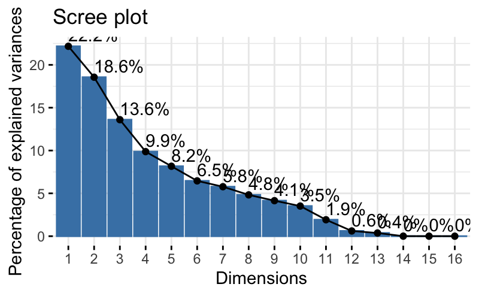

```r
fviz_eig(pr_scale, addlabels = T, ncp = 16)
```

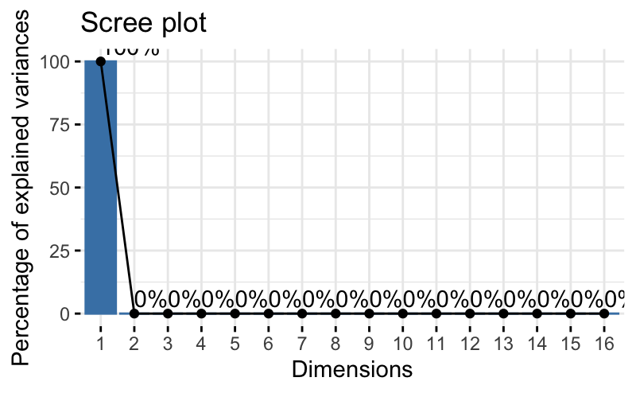

```r
fviz_eig(pr_unscale, addlabels = T, ncp = 16) # Why does the first PC of our unscaled data describe so much more variance than in the scaled data? Features with larger values appear to contribute more to the variance within the data compared to the smaller valued features when unscaled.
```

```r
# Our loadings tell us that features with larger measurement (such as baseline.value) scales tend to contribute more to the PCs than features with smaller values ranges
pr_unscale$rotation
```

```
                        PC1           PC2           PC3           PC4           PC5           PC6           PC7           PC8
Timestamp      1.000000e+00 -7.030453e-08  1.440918e-07 -1.477394e-08  1.475722e-08 -1.190753e-07  7.538857e-09 -5.019473e-09
EDA_Mean      -2.359609e-08 -7.532445e-03 -1.003726e-02  5.088998e-01  8.254428e-02 -2.600235e-01 -1.081120e-03 -2.421512e-02
EDA_Min       -1.788781e-08 -6.306407e-03 -1.013403e-02  4.713348e-01  7.498714e-02 -2.448215e-01  6.731342e-03  2.316442e-02
EDA_Max       -2.853690e-08 -8.661180e-03 -1.151012e-02  5.426930e-01  8.864188e-02 -2.734931e-01 -8.456751e-03  2.885882e-03
EDA_Std       -2.897200e-09 -6.277617e-04 -4.168675e-04  1.973249e-02  2.167536e-03 -8.145280e-03 -4.170756e-03 -1.683903e-03
EDA_Kurtosis  -1.330070e-08  1.184800e-03 -5.718790e-03 -1.465049e-01  9.845723e-01  2.494496e-02  1.725436e-03 -9.174116e-02
EDA_Skew       5.705323e-09  8.926819e-04 -2.101760e-02 -1.830234e-02  9.030674e-02 -6.236038e-03  6.953128e-04  9.946234e-01
EDA_Num_Peaks -1.584155e-08  2.848185e-03  8.859847e-02 -2.117702e-03 -4.577545e-03 -6.822118e-03 -1.088332e-04  2.717391e-02
EDA_Amphitude -4.404692e-09 -9.204510e-04  4.518828e-03  2.710760e-02  2.001480e-03 -7.763726e-03 -5.483741e-03 -2.219882e-03
EDA_Duration  -1.371710e-07  2.036283e-02  9.943694e-01  3.600183e-02  1.265960e-02  3.352505e-02  3.988859e-04  1.850702e-02
HR_Mean       -4.128915e-08 -5.778823e-01  1.179763e-02 -3.705394e-03 -9.061726e-05  9.821628e-03  1.454239e-02  1.311218e-03
HR_Min        -4.008396e-08 -5.647983e-01  9.063316e-03  1.809451e-02  1.171565e-03  4.787457e-02  6.570395e-01  4.071178e-04
HR_Max        -4.247641e-08 -5.884917e-01  1.416620e-02 -2.526240e-02 -9.641591e-04 -3.015688e-02 -6.412034e-01  5.864990e-04
HR_Std        -6.972555e-10 -6.905561e-03  1.484060e-03 -1.273097e-02 -6.381863e-04 -2.293451e-02 -3.831916e-01 -1.246172e-05
HR_RMS        -1.267299e-10 -1.213439e-03  2.707987e-04 -2.389962e-03 -1.223334e-04 -4.310684e-03 -7.226230e-02 -3.877783e-05
temp_Mean      6.912071e-08  5.335691e-03 -2.661965e-02  2.575996e-01  2.566766e-02  5.137116e-01 -3.974370e-02  5.296814e-03
temp_Min       6.954660e-08  5.451873e-03 -2.649284e-02  2.570297e-01  2.524841e-02  5.146344e-01 -3.854955e-02  4.617099e-03
temp_Max       6.878788e-08  5.238416e-03 -2.672058e-02  2.579852e-01  2.605918e-02  5.129352e-01 -4.065775e-02  5.998513e-03
temp_Std      -2.301000e-10 -6.417019e-05 -7.076083e-05  2.848129e-04  2.414518e-04 -5.229115e-04 -6.140919e-04  4.705902e-04
                        PC9          PC10          PC11          PC12          PC13          PC14          PC15          PC16
Timestamp      2.593772e-09  6.956079e-09 -5.852294e-10 -1.424415e-12  1.256589e-10  6.857420e-11  1.152631e-11 -1.134551e-11
EDA_Mean       4.761569e-04 -2.668035e-02  2.103790e-02  1.840217e-03 -4.446599e-02 -8.129360e-01  3.867268e-03  5.370023e-03
EDA_Min        1.630630e-02 -6.015699e-01  3.272879e-01 -1.917405e-03  5.942206e-02  4.185735e-01 -1.755565e-03 -3.069944e-03
EDA_Max       -1.393206e-02  5.160193e-01 -3.366466e-01  2.493913e-04 -1.131605e-02  3.959855e-01 -2.167859e-03 -2.252578e-03
EDA_Std       -1.001089e-02  3.202127e-01 -2.129582e-01  1.436221e-03 -2.510892e-02  4.871792e-02  8.634956e-04 -2.153687e-03
EDA_Kurtosis   7.516136e-03 -1.029426e-03  2.582670e-03  1.584107e-04 -2.999350e-05  3.268569e-03 -1.311256e-05 -3.534146e-05
EDA_Skew      -2.520863e-02  1.341383e-02 -3.203094e-03 -4.240427e-04 -3.714722e-03 -3.012150e-02  1.560388e-04  1.089216e-04
EDA_Num_Peaks  9.948464e-01  4.713462e-03 -3.927479e-02 -3.927737e-03  5.137456e-03 -2.392064e-03  4.680502e-05 -5.984120e-06
EDA_Amphitude  3.109218e-02  5.154646e-01  8.552402e-01  9.207179e-03 -1.170533e-03  2.586823e-02 -1.884894e-04 -1.047584e-03
EDA_Duration  -8.877683e-02 -3.057214e-03 -9.801223e-04  1.357180e-04 -2.861580e-04  1.127084e-04  6.695992e-06 -9.518353e-06
HR_Mean        3.607788e-03 -5.471602e-03 -6.003755e-03  8.157275e-01  6.532236e-03  1.152676e-03 -6.216292e-03  3.906875e-03
HR_Min        -3.458218e-04  9.607578e-03  1.890238e-03 -4.098859e-01 -2.618093e-03 -1.023897e-03  2.016164e-01 -1.945214e-01
HR_Max        -1.325830e-03 -5.939427e-03  3.898002e-03 -4.078016e-01 -4.021452e-03 -1.756521e-04 -1.953720e-01  1.903790e-01
HR_Std        -2.818343e-04 -5.230745e-03  3.513036e-04  1.043847e-02 -3.283233e-03  5.686778e-04  7.782399e-01 -4.966054e-01
HR_RMS        -1.786226e-04 -6.083136e-04 -8.798694e-04  8.420547e-06  1.634374e-02 -9.077472e-03 -5.615324e-01 -8.240529e-01
temp_Mean      6.102705e-03 -1.811274e-03 -2.540196e-03 -1.340677e-03  4.998477e-02 -3.855168e-03 -3.688532e-04 -1.852740e-03
temp_Min       1.078952e-02 -3.762288e-02  1.637913e-02  5.346706e-03 -6.625506e-01  3.668536e-02 -7.142320e-03 -6.231941e-03
temp_Max       2.200746e-03  2.605006e-02 -1.740425e-02 -4.657883e-03  6.143980e-01 -3.354169e-02  7.414351e-03  8.269610e-03
temp_Std      -2.601968e-03  1.976974e-02 -1.132912e-02 -3.046256e-03  4.176019e-01 -2.428051e-02  6.034296e-03  7.883298e-03
```

[output cut: 20 more lines]

We can also looks at these in tabular form

```r
get_eig(pr_scale)
```

|  | eigenvalue | variance.percent | cumulative.variance.percent |
| --- | --- | --- | --- |
| Dim.1 | 4.212176e+00 | 2.216935e+01 | 22.16935 |
| Dim.2 | 3.526255e+00 | 1.855923e+01 | 40.72858 |
| Dim.3 | 2.583926e+00 | 1.359961e+01 | 54.32820 |
| Dim.4 | 1.875513e+00 | 9.871120e+00 | 64.19932 |
| Dim.5 | 1.551484e+00 | 8.165703e+00 | 72.36502 |
| Dim.6 | 1.227029e+00 | 6.458050e+00 | 78.82307 |
| Dim.7 | 1.097554e+00 | 5.776601e+00 | 84.59967 |
| Dim.8 | 9.162986e-01 | 4.822624e+00 | 89.42230 |
| Dim.9 | 7.877319e-01 | 4.145957e+00 | 93.56825 |
| Dim.10 | 6.686363e-01 | 3.519138e+00 | 97.08739 |

[output cut: 9 more lines]

To create our biplot, we’ll use the factoextra package

[figure not shown]

```r
fviz_pca_biplot(pr_scale)
```

If we know our class labels, we can actually take this visualization one step further

[figure not shown]

```r
fviz_pca_biplot(pr_scale, habillage = data$Stress_level)
```

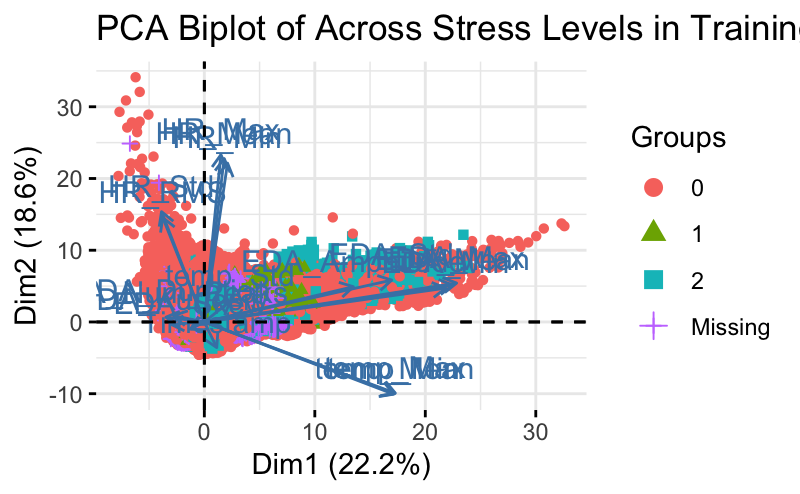

```r
# Easier data visualization using factoextra
fviz_pca_biplot(pr_scale,
             col.ind = 'coord',
             habillage = data$Stress_level, label = "var", title = "PCA Biplot of Across Stress Levels in Training Data")
```